# Dealing with Imbalanced Datasets in a Classification Problem

## Importing Necessary Packages

```python
import numpy as np #python library for working with arrays
import pandas as pd # for working with datasets

#Graphs
import matplotlib.pyplot as plt #visualization
from matplotlib import pyplot #visualization
%matplotlib inline
#static images of your plot embedded in the workbook

#For splitting the train and test data
from sklearn.model_selection import train_test_split

#For Sampling
from sklearn.utils import resample

#XGBoost Algorithm
import xgboost as xgb

#Evaluation
from sklearn import metrics
from sklearn.metrics import confusion_matrix
from sklearn.metrics import precision_score, recall_score, f1_score, accuracy_score

import warnings
warnings.filterwarnings("ignore")
```

```python
pd.options.display.max_colwidth = 150 #to extend the maximum width of the output display
```

## Reading the Dataset

About the Dataset:

Insurance companies that sell life, health, and property and casualty insurance are using machine learning (ML) to drive improvements in customer service, fraud detection, and operational efficiency. We can build a model to predict whether the policyholders (customers) from past year will also be interested in Vehicle Insurance provided by the company.

We have information about:

Demographics (gender, age, region code type), Vehicles (Vehicle Age, Damage), Policy (Premium, sourcing channel), etc.

Aim:

Building a model to predict whether a customer would be interested in Vehicle Insurance is extremely helpful for the company because it can then accordingly plan its communication strategy to reach out to those customers and optimize its business model and revenue.

Data Source: Kaggle - Learning from Imbalanced Insurance Data.

For more information, refer to: https://www.kaggle.com/datasets/arashnic/imbalanced-data-practice

```python
import os
os.chdir("C:\\Users\\Milan\\OneDrive\\Desktop\\AnalyticsVidhya") #changing the directory
```

```python
data = pd.read_csv('aug_train.csv')
```

```python
data.head(10)
```

|  | id | Gender | Age | Driving_License | Region_Code | Previously_Insured | Vehicle_Age | Vehicle_Damage | Annual_Premium | Policy_Sales_Channel | Vintage | Response |
| --- | --- | --- | --- | --- | --- | --- | --- | --- | --- | --- | --- | --- |
| 0 | 167647 | Male | 22 | 1 | 7.0 | 1 | < 1 Year | No | 2630.0 | 152.0 | 16 | 0 |
| 1 | 17163 | Male | 42 | 1 | 28.0 | 0 | 1-2 Year | Yes | 43327.0 | 26.0 | 135 | 0 |
| 2 | 32023 | Female | 66 | 1 | 33.0 | 0 | 1-2 Year | Yes | 35841.0 | 124.0 | 253 | 0 |
| 3 | 87447 | Female | 22 | 1 | 33.0 | 0 | < 1 Year | No | 27645.0 | 152.0 | 69 | 0 |
| 4 | 501933 | Male | 28 | 1 | 46.0 | 1 | < 1 Year | No | 29023.0 | 152.0 | 211 | 0 |
| 5 | 295775 | Female | 25 | 1 | 25.0 | 1 | < 1 Year | No | 27954.0 | 152.0 | 23 | 0 |
| 6 | 71711 | Male | 51 | 1 | 8.0 | 0 | 1-2 Year | Yes | 2630.0 | 26.0 | 209 | 0 |
| 7 | 331781 | Male | 38 | 1 | 28.0 | 1 | 1-2 Year | No | 2630.0 | 26.0 | 51 | 0 |
| 8 | 290704 | Female | 45 | 1 | 28.0 | 0 | 1-2 Year | Yes | 55873.0 | 124.0 | 262 | 0 |
| 9 | 344792 | Male | 42 | 1 | 28.0 | 0 | 1-2 Year | Yes | 27801.0 | 122.0 | 217 | 1 |

## Basic Data Preprocessing

```python
data.isnull().sum().sum() #checking for null values
```

```
0
```

```python
data.dtypes #checking the data types of the various columns
```

```
id                        int64
Gender                   object
Age                       int64
Driving_License           int64
Region_Code             float64
Previously_Insured        int64
Vehicle_Age              object
Vehicle_Damage           object
Annual_Premium          float64
Policy_Sales_Channel    float64
Vintage                   int64
Response                  int64
dtype: object
```

```python
data.describe()
```

[output not shown]

```python
data = pd.get_dummies(data, ['Gender', 'Vehicle_Age', 'Vehicle_Damage']) #one-hot-encoding for Categorical Columns
```

## Check the Class Imbalance

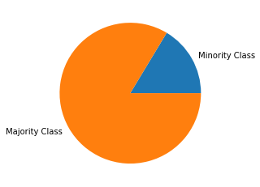

```python
class_division = [ data[data['Response'] == 1 ].shape[0], data[data['Response'] == 0 ].shape[0] ]
my_labels = ['Minority Class', 'Majority Class']

plt.pie(class_division, labels = my_labels)
plt.show()
```

```python
print("Proportion of Minority Class: " + str(round(data[data['Response'] == 1 ].shape[0]/data.shape[0] * 100, 2)) + "%")
```

```
Proportion of Minority Class: 16.38%
```

```python
from sklearn.model_selection import train_test_split #splitting the data into train and test

X = data.drop(columns= ['id', 'Response']) #Columns to be excluded from training set
y = data['Response'] #defining the Response as y

X.columns = ['Age', 'Driving_License', 'Region_Code', 'Previously_Insured',
       'Annual_Premium', 'Policy_Sales_Channel', 'Vintage', 'Gender_Female',
       'Gender_Male', 'Vehicle_Age_1_2_Year', 'Vehicle_Age_lessthan_1_Year',
       'Vehicle_Age_greaterthan_2_Years', 'Vehicle_Damage_No', 'Vehicle_Damage_Yes']

X_train, X_test, y_train, y_test = train_test_split(X, y, test_size=0.3, random_state=42, stratify=y)

# splitting the data into train and test. Note that here, we have used stratify = y, so that the class imbalances are properly
# replicated in our train and test dataset. The data is split in a 70-30 ratio of train:test.
```

We check to ensure that the class imbalance in our population is fairly replicated in our train and test set. Else there will be sampling bias and the sample will not represent the true picture of the population.

```python
print("Proportion of Minority Class in train set: " + str(round(y_train.sum()/len(y_train) * 100, 2)) + "%")
print("Proportion of Minority Class in test set: " + str(round(y_test.sum()/len(y_test) * 100, 2)) + "%")
```

```
Proportion of Minority Class in train set: 16.38%
Proportion of Minority Class in test set: 16.38%
```

## Building a Basic XGBoost Model

We choose an XGBoost model to illustrate the effect of class imbalance in the data. XGBoost models are usually robust, guard against overfitting and do not adhere to many assumptions as in cases of decision trees or logistic regression models. Here we see that inspite of all these qualities, the xgboost model does not perform well in case of the unbalanced dataset.

```python
xgb_classifier = xgb.XGBClassifier()
xgb_classifier.fit(X_train,y_train)
```

```
XGBClassifier(base_score=0.5, booster='gbtree', colsample_bylevel=1,
              colsample_bynode=1, colsample_bytree=1, gamma=0, gpu_id=-1,
              importance_type='gain', interaction_constraints='',
              learning_rate=0.300000012, max_delta_step=0, max_depth=6,
              min_child_weight=1, missing=nan, monotone_constraints='()',
              n_estimators=100, n_jobs=0, num_parallel_tree=1, random_state=0,
              reg_alpha=0, reg_lambda=1, scale_pos_weight=1, subsample=1,
              tree_method='exact', validate_parameters=1, verbosity=None)
```

```python
test = xgb_classifier.predict(X_test)
```

Here, we will check the accuracy of the model and see how it compares to the precision, recall and F1 Score.

```python
print("Accuracy of Test Set:", round(accuracy_score(y_test,test) * 100, 2 ), "%")
```

```
Accuracy of Test Set: 84.58 %
```

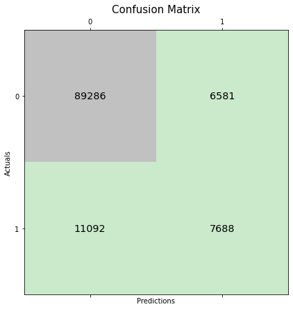

```python
conf_matrix = confusion_matrix(y_true=y_test, y_pred=test)

fig, ax = plt.subplots(figsize=(7, 7))
ax.matshow(conf_matrix, cmap=plt.cm.Accent, alpha=0.4)
for i in range(conf_matrix.shape[0]):
    for j in range(conf_matrix.shape[1]):
        ax.text(x=j, y=i,s=conf_matrix[i, j], va='center', ha='center', size='x-large')

plt.xlabel('Predictions', fontsize=10)
plt.ylabel('Actuals', fontsize=10)
plt.title('Confusion Matrix', fontsize=15)
plt.show()
```

```python
precision_original =  round(precision_score(y_test, test), 4)
recall_original = round(recall_score(y_test, test), 4)
F1_score_original =  round(f1_score(y_test, test), 4)
metrics_original = [precision_original, recall_original, F1_score_original]

original = pd.DataFrame(metrics_original)
original.index = ['Precision', 'Recall', 'F1_score']
original.columns = ['Original Dataset']
original['Comments'] = ['Only 54% of the customers targetted are actually interested in renewing their insurance',
                       'Only 41% of the potentially interested customers are being identified',
                       '']
original
```

|  | Original Dataset | Comments |
| --- | --- | --- |
| Precision | 0.5388 | Only 54% of the customers targetted are actually interested in renewing their insurance |
| Recall | 0.4094 | Only 41% of the potentially interested customers are being identified |
| F1_score | 0.4652 |  |

# Changing the threshold

```python
cols = ['Metrics', 'Original']
adj_threshold = pd.DataFrame()
adj_threshold['Original'] = metrics_original
thresholds = [ j/20 for j in range(1,16)]
for i in thresholds:

    y_pred_new_threshold = (xgb_classifier.predict_proba(X_test)[:,1]>=i).astype(int) #calculating the threshold with respect to class 1

    precision_adj_threshold =  round(precision_score(y_test, y_pred_new_threshold, average='binary'), 4)
    recall_adj_threshold = round(recall_score(y_test, y_pred_new_threshold, average='binary'), 4)
    F1_score_adj_threshold =  round((f1_score(y_test, y_pred_new_threshold, average='binary')), 4)
    metrics_adj_threshold = [precision_adj_threshold, recall_adj_threshold, F1_score_adj_threshold]
    name = 'Threshold: ' + str(i)
    adj_threshold[name] = metrics_adj_threshold
    cols.append(name)


adj_threshold.index = ['Precision', 'Recall', 'F1_score']
adj_threshold = adj_threshold.reset_index()
adj_threshold.columns = cols
adj_threshold.transpose()

adj_threshold1 = adj_threshold.transpose().iloc[1:, :]
adj_threshold1.columns = adj_threshold.iloc[:,0]
adj_threshold1
```

| Metrics | Precision | Recall | F1_score |
| --- | --- | --- | --- |
| Original | 0.5388 | 0.4094 | 0.4652 |
| Threshold: 0.05 | 0.3571 | 0.988 | 0.5246 |
| Threshold: 0.1 | 0.3868 | 0.963 | 0.5519 |
| Threshold: 0.15 | 0.4171 | 0.9257 | 0.5751 |
| Threshold: 0.2 | 0.4451 | 0.8877 | 0.5929 |
| Threshold: 0.25 | 0.4663 | 0.8486 | 0.6019 |
| Threshold: 0.3 | 0.4834 | 0.8116 | 0.6059 |
| Threshold: 0.35 | 0.4983 | 0.7684 | 0.6046 |
| Threshold: 0.4 | 0.5104 | 0.7081 | 0.5932 |
| Threshold: 0.45 | 0.5222 | 0.5895 | 0.5538 |
| Threshold: 0.5 | 0.5388 | 0.4094 | 0.4652 |
| Threshold: 0.55 | 0.5577 | 0.2145 | 0.3098 |
| Threshold: 0.6 | 0.583 | 0.083 | 0.1453 |
| Threshold: 0.65 | 0.585 | 0.0249 | 0.0478 |
| Threshold: 0.7 | 0.5991 | 0.0074 | 0.0146 |
| Threshold: 0.75 | 0.5312 | 0.0018 | 0.0036 |

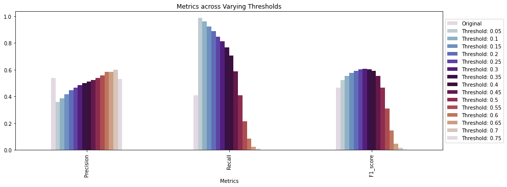

```python
adj_threshold.plot(x='Metrics',
        kind='bar',
        stacked=False,
        title='Metrics across Varying Thresholds',
        figsize=(15, 5),
        cmap = 'twilight').legend(loc='center left',bbox_to_anchor=(1.0, 0.5))
```

## New Classifier with Optimal Threshold

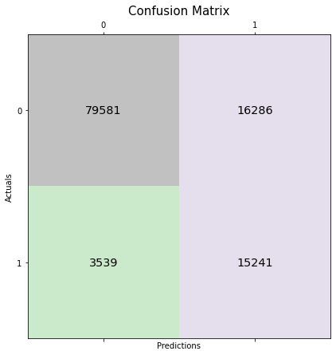

```python
y_pred_new_threshold = (xgb_classifier.predict_proba(X_test)[:,1]>=0.3).astype(int)


conf_matrix = confusion_matrix(y_true=y_test, y_pred=y_pred_new_threshold)

fig, ax = plt.subplots(figsize=(7, 7))
ax.matshow(conf_matrix, cmap=plt.cm.Accent, alpha=0.4)
for i in range(conf_matrix.shape[0]):
    for j in range(conf_matrix.shape[1]):
        ax.text(x=j, y=i,s=conf_matrix[i, j], va='center', ha='center', size='x-large')

plt.xlabel('Predictions', fontsize=10)
plt.ylabel('Actuals', fontsize=10)
plt.title('Confusion Matrix', fontsize=15)
plt.show()
```

```python
precision_changedthreshold =  round(precision_score(y_test, y_pred_new_threshold), 4)
recall_changedthreshold = round(recall_score(y_test, y_pred_new_threshold), 4)
F1_changedthreshold =  round(f1_score(y_test, y_pred_new_threshold), 4)
metrics_changedthreshold = [precision_changedthreshold, recall_changedthreshold, F1_changedthreshold]

changedthreshold = pd.DataFrame(list(zip(metrics_original, metrics_changedthreshold)))
changedthreshold.index = ['Precision', 'Recall', 'F1_score']
changedthreshold.columns = ['Original Dataset', 'Threshold Changed Dataset']
changedthreshold
```

|  | Original Dataset | Threshold Changed Dataset |
| --- | --- | --- |
| Precision | 0.5388 | 0.4834 |
| Recall | 0.4094 | 0.8116 |
| F1_score | 0.4652 | 0.6059 |

# Oversampling

We will show oversampling where the minority and majority class match in proportion.

```python
#Oversampling
train_data=pd.concat([X_train,y_train],axis=1)

Response_Zero=train_data[train_data.Response==0]
Response_One=train_data[train_data.Response==1]

upsampled_One = resample(Response_One,
                          replace=True, # sample with replacement
                          n_samples=len(Response_Zero), # match number in majority class
                          random_state=27) # reproducible results

# combine majority and upsampled minority
upsampled = pd.concat([Response_Zero, upsampled_One])
```

```python
#Distribution of data in the train set before over-sampling
y_train.value_counts()
```

```
0    223686
1     43821
Name: Response, dtype: int64
```

```python
#Distribution of data in the train set after over-sampling
upsampled['Response'].value_counts()
```

```
1    223686
0    223686
Name: Response, dtype: int64
```

```python
#Training the model on up-sampled data
X_train_upsampled = upsampled.drop(columns = ['Response'])
y_train_upsampled = upsampled['Response']

xgb_upsampled = xgb.XGBClassifier()

xgb_upsampled.fit(X_train_upsampled,y_train_upsampled)

train_upsampled = xgb_upsampled.predict(X_train_upsampled)
test_upsampled = xgb_upsampled.predict(X_test)
```

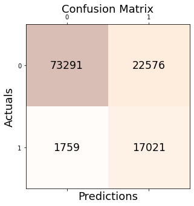

```python
#Confusion matrix on the test set
conf_matrix = confusion_matrix(y_true=y_test, y_pred=test_upsampled)

fig, ax = plt.subplots(figsize=(5, 5))
ax.matshow(conf_matrix, cmap=plt.cm.Oranges, alpha=0.3)
for i in range(conf_matrix.shape[0]):
    for j in range(conf_matrix.shape[1]):
        ax.text(x=j, y=i,s=conf_matrix[i, j], va='center', ha='center', size='xx-large')

plt.xlabel('Predictions', fontsize=18)
plt.ylabel('Actuals', fontsize=18)
plt.title('Confusion Matrix', fontsize=18)
plt.show()
```

```python
#New efficacy metrics
precision_upsampled =  round(precision_score(y_test, test_upsampled), 4)
recall_upsampled = round(recall_score(y_test, test_upsampled), 4)
F1_upsampled =  round(f1_score(y_test, test_upsampled), 4)
metrics_upsampled = [precision_upsampled, recall_upsampled, F1_upsampled]

upsampled = pd.DataFrame(list(zip(metrics_original, metrics_changedthreshold, metrics_upsampled)))
upsampled.index = ['Precision', 'Recall', 'F1_score']
upsampled.columns = ['Original Dataset', 'Threshold = 0.3', 'Upsampled Dataset']
upsampled
```

|  | Original Dataset | Threshold = 0.3 | Upsampled Dataset |
| --- | --- | --- | --- |
| Precision | 0.5388 | 0.4834 | 0.4299 |
| Recall | 0.4094 | 0.8116 | 0.9063 |
| F1_score | 0.4652 | 0.6059 | 0.5831 |

# Undersampling

```python
#down-sampling
downsampled_Zero = resample(Response_Zero,
                                replace = False, # sample without replacement
                                n_samples = len(Response_One), # match minority n
                                random_state = 27) # reproducible results

#combine minority and downsampled majority
downsampled = pd.concat([downsampled_Zero, Response_One])
```

```python
#Distribution of majority and minority classes
y_train.value_counts()
```

```
0    223686
1     43821
Name: Response, dtype: int64
```

```python
#Distribution of both the classes after down-sampling
downsampled['Response'].value_counts()
```

```
1    43821
0    43821
Name: Response, dtype: int64
```

```python
#Training the model on down-sampled data and testing on the original test dataset
X_train_downsampled = downsampled.drop(columns = ['Response'])
y_train_downsampled = downsampled['Response']

xgb_downsampled = xgb.XGBClassifier()

xgb_downsampled.fit(X_train_downsampled,y_train_downsampled)

train_downsampled = xgb_downsampled.predict(X_train_downsampled)
test_downsampled = xgb_downsampled.predict(X_test)
```

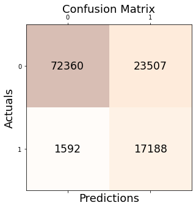

```python
#Confusion metrics of the model built on down-sampled data
conf_matrix = confusion_matrix(y_true=y_test, y_pred=test_downsampled)

fig, ax = plt.subplots(figsize=(5, 5))
ax.matshow(conf_matrix, cmap=plt.cm.Oranges, alpha=0.3)
for i in range(conf_matrix.shape[0]):
    for j in range(conf_matrix.shape[1]):
        ax.text(x=j, y=i,s=conf_matrix[i, j], va='center', ha='center', size='xx-large')

plt.xlabel('Predictions', fontsize=18)
plt.ylabel('Actuals', fontsize=18)
plt.title('Confusion Matrix', fontsize=18)
plt.show()
```

```python
#Final Metrics

precision_downsampled =  round(precision_score(y_test, test_downsampled), 4)
recall_downsampled = round(recall_score(y_test, test_downsampled), 4)
F1_downsampled =  round(f1_score(y_test, test_downsampled), 4)
metrics_downsampled = [precision_downsampled, recall_downsampled, F1_downsampled]

downsampled = pd.DataFrame(list(zip(metrics_original, metrics_changedthreshold,  metrics_upsampled, metrics_downsampled)))
downsampled.index = ['Precision', 'Recall', 'F1_score']
downsampled.columns = ['Original Dataset', 'Threshold = 0.3', 'Upsampled Dataset', 'Downsampled Dataset']
downsampled
```

|  | Original Dataset | Threshold = 0.3 | Upsampled Dataset | Downsampled Dataset |
| --- | --- | --- | --- | --- |
| Precision | 0.5388 | 0.4834 | 0.4299 | 0.4224 |
| Recall | 0.4094 | 0.8116 | 0.9063 | 0.9152 |
| F1_score | 0.4652 | 0.6059 | 0.5831 | 0.5780 |